# R俱乐部

## day01

### 杜 月新

### RStudio

### 2020/10/12

# 日程安排

*参考网页链接（李　東風）*

http://www.math.pku.edu.cn/teachers/lidf/docs/Rbook/html/_Rbook/stat-reg.html

|            | 标题                 | 教材对应处   | 回数 |
|------------|----------------------|--------------|------|
| 介绍       | Rstudio的介绍         | Section1+2   | ①    |
| R统计分析  | 图表的介绍与概率分布  | Section32.1  | ②    |
|            | 检定与信赖区间        | Section32.3  | ③    |
| 相关与回归 | 相关分析              | Section33.1  | ④    |
|            | 单回归分析与多回归分析| Section33.2  | ⑤    |
|            | Logistic回归分析      | Section33.5  | ⑥    |
|  运用      |  ggplot的运用         | Section30+31| ⑦    |
|            |  中国地图与日本地图的绘制|      | ⑧    |

# R语言和R软件

-R的主网站在https://www.r-project.org/

-自由软件，免费、开放源代码，支持各个主要计算机系统；

-完整的程序设计语言，基于函数和对象，可以自定义函数，调入C、C++、Fortran编译的代码；

-具有完善的数据类型，如向量、矩阵、因子、数据集、一般对象等，支持缺失值，代码像伪代码一样简洁、可读;

等等...

>RStudio（https://www.rstudio.com/): 功能更强的一个R图形界面，在安装好R的官方版本后安装RStudio可以更方便地使用R。

# Rstudio的介绍

-Rstudio的下载以及界面的介绍

- 界面一般分为四个窗口，其中脚本编辑器与控制台（Console）是最重要的两个窗格。
 - 控制台：启动R软件后进入控制台，每输入一行命令，就在后面显示计算结果。可以用向上和向下箭头访问历史命令；

- 脚本编辑器:可以用New File–Script file功能建立一个源程序文件（脚本文件）， 在脚本文件中写程序，然后用Run图标或者Ctrl+Enter键运行当前行或者选定的部分。

- Files: 列出当前项目的目录（文件夹）内容。

- Plots: 如果程序中有绘图结果，将会显示在这个窗格。 因为绘图需要足够的空间，所以当屏幕分辨率过低或者Plots窗格太小的时候，可以点击“Zoom”图标将图形显示在一个单独的窗口中，或者将图形窗口作为唯一窗格显示。

- Help: R软件的文档与RStudio的文档都在这里。
 - ？mean

- Environment:已经有定义的变量、函数都显示在这里。

- History: 以前运行过的命令都显示在这里。不限于本次RStdudio运行期间，也包括以前使用RStudio时运行过的命令。

- Packages: 显示已安装的R扩展包及其文档。

- Viewer, Connection等窗格。

[figure not shown]

*Rstudio的用途*
- RStudio软件是R软件的应用界面与增强系统， 可以在其中编辑、运行R的程序文件，可以跟踪运行,还可以构造文字、R结果图表融合在一起的研究报告、论文、图书、网站等。

#开始简单的运用
**ⅱ 四则运算**

```r
10 + 5                             # 加法
```

```r
1-3                                # 减法
```

```r
3*0.33                             # 乘法
```

```r
1/4                                # 除法
```

```r
2^10                               # 次方
```

```r
10%/%3                             # 商
```

```r
10%%3                              # 余数
```

```r
1+2*2                              # 乘法除法优先于加法减法
```

**ⅲ数学函数**
- 数学函数——平方根、指数、对数

```r
sqrt(6.25)
```

```
## [1] 2.5
```

```r
exp(1)
```

```
## [1] 2.718282
```

```r
log10(10000)
```

```
## [1] 4
```

**ⅳ变数**

`\((1+2+4)/(0.5^2)\)`

```r
x=1+2+4

y=0.5^2

x/y
```

```
## [1] 28
```

- 名字=式子
   - 或者
- 名字<- 式子

最后，命名计算结果即可。

#问题
某人存入10000元1年期定期存款，年利率3%,约定到期自动转存（包括利息）。

问：

1.10年后本息共多少元？

2.需要存多少年这10000元才能增值到20000元？

1.

```r
10000*(1+0.03)^10
```

```
## [1] 13439.16
```

2.

```r
log(2)/log(1.03)
```

```
## [1] 23.44977
```

**ⅴ.向量计算与变量赋值**

* R语言以向量为最小单位。用<-(或者=)赋值。例如：

```r
 x1=1:10
 x1
```

```
 ##  [1]  1  2  3  4  5  6  7  8  9 10
```

-也可用c( )生成，如:

```r
marks <- c(3, 5, 10, 5, 6)
```

* 在命令行中显示向量时,每行显示的行首会有方括号和数字序号，代表该行显示的第一个向量元素的下标。如:

```r
8901:8920
```

```
##  [1] 8901 8902 8903 8904 8905 8906 8907 8908 8909 8910 8911 8912 8913 8914 8915
## [16] 8916 8917 8918 8919 8920
```

另外

* 向量可以和一个标量作四则运算，结果是每个元素都和这个标量作四则运算。
两个等长的向量可以进行四则运算，相当于对应元素进行四则运算(**注意：不等长的情况下也可以计算**)。如：

```r
x1+200
```

```
##  [1] 201 202 203 204 205 206 207 208 209 210
```

```r
x2=x1*3
```

```r
x2-x1
```

```
##  [1]  2  4  6  8 10 12 14 16 18 20
```

* R的许多函数都可以用向量作为自变量，结果是自变量的每个元素各自的函数值。如:

```r
sqrt(x1)
```

```
##  [1] 1.000000 1.414214 1.732051 2.000000 2.236068 2.449490 2.645751 2.828427
##  [9] 3.000000 3.162278
```

**ⅵ分布函数**
*命名规则*

d.... => 概率密度函数(density)

p.... => 累积分布函数 (probability)

q.... => 累积分布函数的反函数 (quantile)

r.... => 疑似乱数生成器 (random)

>例（正规分布）

```r
dnorm(1.98)         #正态分布的概率密度函数
```

```r
pnorm(1.98)         #正态分布的累积分布函数
```

```r
qnorm(0.975)        #正态分布的累积分布函数的反函数
```

```r
rnorm(2)            #符合正态分布的随机数
```

**随机数**
*rnorm(n)*

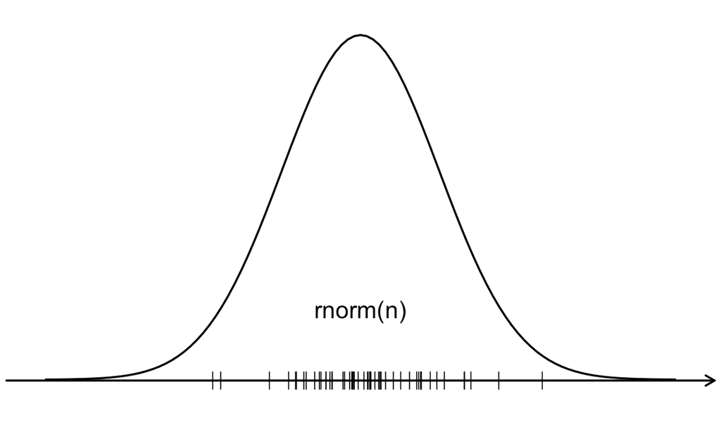

**累积分布函数**
*pmorm(q)*

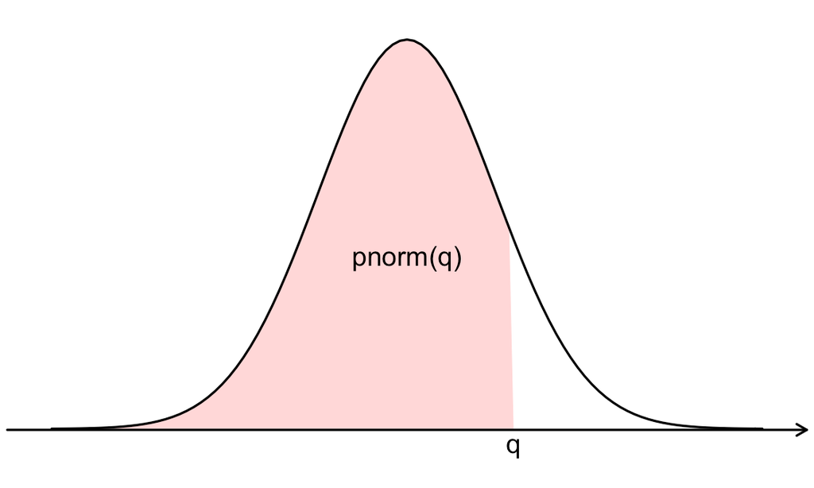

**累积分布函数的反函数**
*qmorm(p)*

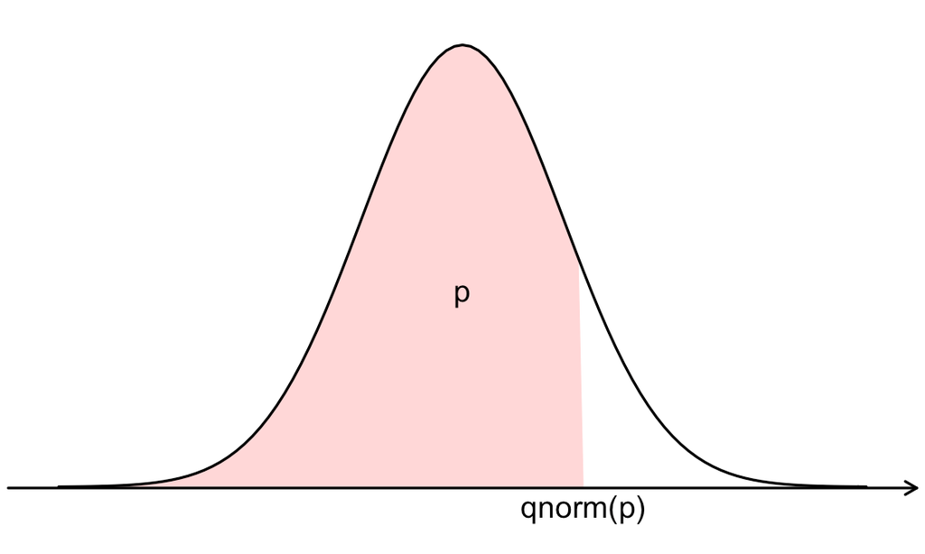

# 例 乱数（random number)

rnorm(n,....)→符合正态分布的随机数
hist()→柱形图

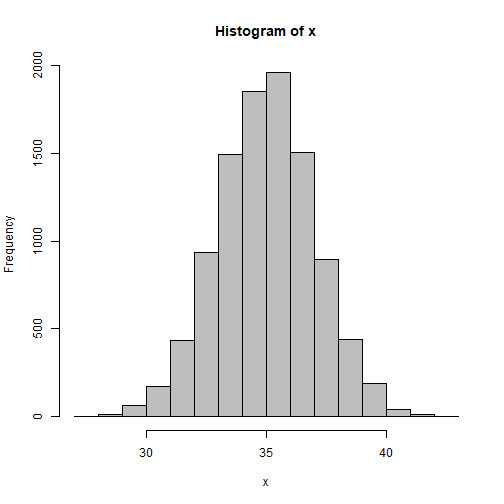

```r
x=rnorm(10000, mean=35,sd=2)
hist(x,col="gray")
```

**试一试**

-[0,1)上的均匀分布：平均值为1/2，分散值为1/12

-runif（n):在均匀分布上，生成一系列乱数

* mean（n）：计算标本平均

```r
 n=1000
 z=(mean(runif(n)) - 0.5) / sqrt((1/12) / n)
 z
```

```
 ## [1] 0.086573
```

*注意：这里，只可以实现一个Z值。如果要反复实现，R中可以用代码replicate（ ）。

*使用replicate（ ）进行反复处理*

```r
z=replicate(1000, mean(runif(n)) - 0.5) / sqrt((1/12) / n)
head(z)
```

```
## [1] -1.2035803  0.4524094  0.4920106  0.8061573  1.3625952 -0.8121963
```

-这里即是得出了1000个（把随机变数标准化后的)Z值。

*生成柱形图*

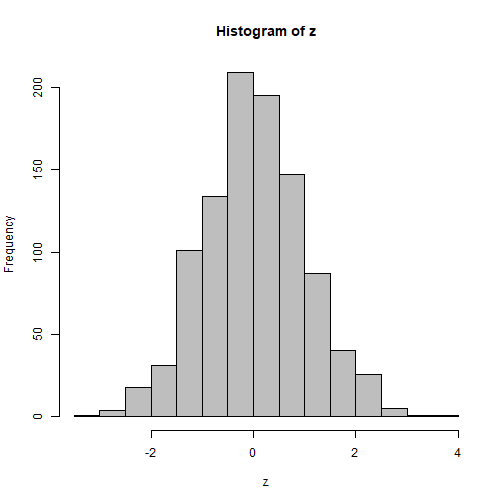

```r
hist(z,col="gray")       #应该时呈现正规分布
```

**ⅶ数据框  data.frame**

-统计分析中最常见的原始数据形式是类似于数据库表或Excel数据表的形式。这样形式的数据在R中叫做数据框(data.frame)。

-函数data.frame()可以生成数据框
 如：

```r
Height = c(168.5, 172.8, 159.0)
Weight = c(69.5, 75.0, 56.5)
X = data.frame(Height, Weight)
X
```

```
##   Height Weight
## 1  168.5   69.5
## 2  172.8   75.0
## 3  159.0   56.5
```

```r
X$Height
```

```
## [1] 168.5 172.8 159.0
```

-列的追加⇒round

```r
X$BMI = round(X$Weight / (X$Height / 100)^2)
X
```

```
##   Height Weight BMI
## 1  168.5   69.5  24
## 2  172.8   75.0  25
## 3  159.0   56.5  22
```

-导出数据

```r
write.csv(X,"C:/Users/dyx19/OneDrive/yuexin/test.csv")
```

**程序包的运用**

大多数时候，我们不需要直接入力，可以利用事先做好的Excel或者CSV等等。

—首先安装读取Excel表格的程序包

```r
install.packages("readxl")
```

-接下来我们就可以读取事先准备好的Excel表格

```r
library(readxl)
read_excel("test.xlsx")
```

**接下里让我们来试一下吧！**

—先做一张test.xlsx表格。

-保存在以下表示的路径的文件包里。

```r
getwd()
```

[output not shown]

-最后，在Rstudio里实行刚刚的操作。

# R-project 的运用

- 用Rproject管理工作目录

- 所谓工作目录就是默认的读取和储存位置，也就是说，R语言只能和一个文件夹进行互动

- 对于每次进行的操作，想要保存的情况下，建议每次一开始创建一个新的project。

- 例如想要保存自己的作业等等。

**从零新建R-project**
- step：

1.右上角Project右侧倒三角，菜单中点击New Project可以创建新项目。

[figure not shown]

横线下面的是已经创建过的项目名，可以点击切换到其他项目。

2.创建新项目时需要指定一个文件夹，最好是一个新的文件夹。以后产生的R代码，图片都会默认存在这个文件夹下。

**从存在文件夹创建R-project**

- step

1.打开RStudio 点击 File -> New Project....

2.选择Existing Directory

3.点击 Browse ，找到自己的项目文件夹

4.最后点击 Create Project.

**显示文件列表**
- dir（）

```r
dir()
```

```
##  [1] "day01.html"   "day01.Rmd"    "day01.Rproj"  "day01_files"  "home.png"
##  [6] "pnorm(q).png" "qnorm(p).png" "rnorm(n).png" "rproject.png" "rstudio.png"
```